# Practical Machine Learning - Course Project

Florian Ulmar

Januar 2016

# Background

Using devices such as Jawbone Up, Nike FuelBand, and Fitbit it is now possible to collect a large amount of data about personal activity relatively inexpensively. These type of devices are part of the quantified self movement – a group of enthusiasts who take measurements about themselves regularly to improve their health, to find patterns in their behavior, or because they are tech geeks. One thing that people regularly do is quantify how much of a particular activity they do, but they rarely quantify **how well** they do it.

In this project, we will use data from accelerometers on the belt, forearm, arm, and dumbell of 6 participants. They were asked to perform barbell lifts correctly and incorrectly in 5 different ways. More information is available from the website here: http://groupware.les.inf.puc-rio.br/har (see the section on the Weight Lifting Exercise Dataset).

The goal of your project is to predict the manner in which they did the exercise. This is the “classe” variable in the training set.

# Getting and cleaning the data

The training data for this project are available here:

https://d396qusza40orc.cloudfront.net/predmachlearn/pml-training.csv

The test data are available here:

https://d396qusza40orc.cloudfront.net/predmachlearn/pml-testing.csv

The data for this project come from this source:

http://groupware.les.inf.puc-rio.br/har.

We first download the data and convert empty values into NAs.

```r
# downloading files from url
pml_training_file <- './pml-training.csv' # Data for for training and cross validation
pml_testing_file <- './pml-testing.csv' # Data for testcases
pml_training_url <- 'https://d396qusza40orc.cloudfront.net/predmachlearn/pml-training.csv'
pml_testing_url <- 'https://d396qusza40orc.cloudfront.net/predmachlearn/pml-testing.csv'
# download.file(pml_training_url, pml_training_file)
# download.file(pml_testing_url, pml_testing_file)

pml <- read.csv(file = pml_training_file, header = T, na.strings = c("NA", "" ,"#DIV/0!"))
dim(pml)
```

```
## [1] 19622   160
```

For the further analysis it is important to remove columns with NAs. Additionally we remove factor-variables with different levels with regard to the test cases. We also remove some further variables which are not relevant for our model.

```r
pml <- subset(pml[, colSums(is.na(pml)) == 0],
              select = -c(X, user_name, new_window, num_window, raw_timestamp_part_1, raw_timestamp_part_2, cvtd_timestamp))
dim(pml)
```

```
## [1] 19622    53
```

# Data Analysis

## Creating training and test data

We first want to split our dataset into a training and a testing set.

```r
set.seed(333)
library("caret")
library("randomForest")
library("rattle")

inTrain <- createDataPartition(pml$classe, p = 0.7, list = F)
training <- pml[inTrain,]
testing <- pml[-inTrain,]
dim(training); dim(testing)
```

```
## [1] 13737    53
```

```
## [1] 5885   53
```

## Predicting with trees

As a first approach we want to model the training set by a decision tree. In this algorithm, the variables are splitted iteratively into groups and the homogenity is evaluated for each group.

```r
tm <- system.time(
    model <- train(classe ~ ., method="rpart", data=training)
)
print(tm)
```

```
##    user  system elapsed
##   18.63    0.39   19.07
```

```r
print(model$finalModel)
```

```
## n= 13737
##
## node), split, n, loss, yval, (yprob)
##       * denotes terminal node
##
##  1) root 13737 9831 A (0.28 0.19 0.17 0.16 0.18)
##    2) roll_belt< 130.5 12577 8681 A (0.31 0.21 0.19 0.18 0.11)
##      4) pitch_forearm< -34.35 1126    3 A (1 0.0027 0 0 0) *
##      5) pitch_forearm>=-34.35 11451 8678 A (0.24 0.23 0.21 0.2 0.12)
##       10) magnet_dumbbell_y< 437.5 9655 6948 A (0.28 0.18 0.24 0.19 0.11)
##         20) roll_forearm< 123.5 5969 3551 A (0.41 0.18 0.18 0.17 0.062) *
##         21) roll_forearm>=123.5 3686 2452 C (0.078 0.17 0.33 0.23 0.18) *
##       11) magnet_dumbbell_y>=437.5 1796  873 B (0.037 0.51 0.04 0.22 0.19) *
##    3) roll_belt>=130.5 1160   10 E (0.0086 0 0 0 0.99) *
```

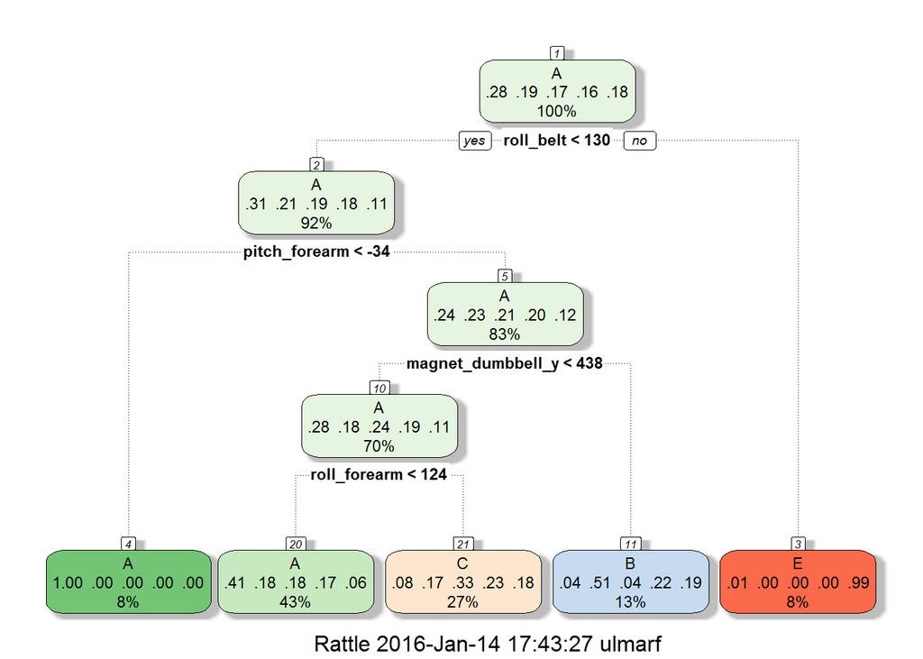

```r
fancyRpartPlot(model$finalModel)
```

```r
## cross validation
pred <- predict(model, newdata = testing)
confMatrix <- confusionMatrix(testing$classe, pred)
print(confMatrix$table)
```

```
##           Reference
## Prediction    A    B    C    D    E
##          A 1530   24  116    0    4
##          B  479  373  287    0    0
##          C  495   38  493    0    0
##          D  438  181  345    0    0
##          E  153  154  294    0  481
```

```r
print(confMatrix$overall[1])
```

```
## Accuracy
##  0.48887
```

As we can see the accuracy of the model is very poor.

### Random Forest model

A much better approach is given by the Random Forest algorithm. This algorithm generates a lot of trees by bootstrapping samples of the data. At each split, the variables are also bootstrapped.

```r
tm <- system.time(
    model <- randomForest(classe ~ ., data = training, ntree = 100, importance = FALSE)
)
print(tm)
```

```
##    user  system elapsed
##    7.98    0.00    7.99
```

```r
## the train function of the caret package is very time consuming
# ctrl <- trainControl(allowParallel = T, method = "cv", number = 3)
# model <- train(classe ~ ., data = training, model = "rf", trControl= ctrl)

pred <- predict(model, newdata = testing)
confMatrix <- confusionMatrix(testing$classe, pred)
print(confMatrix$table)
```

```
##           Reference
## Prediction    A    B    C    D    E
##          A 1672    2    0    0    0
##          B    3 1135    1    0    0
##          C    0    6 1018    2    0
##          D    0    0   10  954    0
##          E    0    0    1    1 1080
```

```r
print(confMatrix$overall[1])
```

```
## Accuracy
## 0.995582
```

Simulations show that the train function of the caret-package is very time consuming. For that reason we take the *randomForest*-Function of the corresponding package. As we can see we get a much better accuracy as in the previous model.

Even if take only the first 10 most important variables into account the results have nearly the same accuracy.

```r
# reduced model
ord <- order(varImp(model), decreasing = T)
small <- ord[1:10]
trainSmall <- training[, c(small, dim(training)[2])]
testSmall <- testing[, c(small, dim(testing)[2])]
tm <- system.time(
    modelSmall <- randomForest(classe ~ ., data = trainSmall, ntree = 100, importance = FALSE)
)
print(tm)
```

```
##    user  system elapsed
##    1.85    0.02    1.88
```

```r
pred <- predict(modelSmall, newdata = testSmall)
confMatrixSmall <- confusionMatrix(testSmall$classe, pred)
print(confMatrixSmall$table)
```

```
##           Reference
## Prediction    A    B    C    D    E
##          A 1663    5    4    2    0
##          B   10 1098   25    6    0
##          C    2    7 1009    8    0
##          D    0    0   11  952    1
##          E    0    5    3    4 1070
```

```r
print(confMatrixSmall$overall[1])
```

```
##  Accuracy
## 0.9841971
```

### Test Cases

At last we want to predict the outcome for 20 test cases in the test data file. For this simulation we take the random forest models from the previous section.

```r
testCases <- read.csv(file = pml_testing_file, header = T, na.strings = c("NA", "" ,"#DIV/0!"))
testCases <- subset(testCases[, colSums(is.na(testCases)) == 0],
                 select=-c(X, user_name, new_window, num_window, raw_timestamp_part_1, raw_timestamp_part_2, cvtd_timestamp))
dim(testCases)
```

```
## [1] 20 53
```

```r
pred <- predict(model, newdata = testCases)
print(pred)
```

```
##  1  2  3  4  5  6  7  8  9 10 11 12 13 14 15 16 17 18 19 20
##  B  A  B  A  A  E  D  B  A  A  B  C  B  A  E  E  A  B  B  B
## Levels: A B C D E
```

```r
predSmall <- predict(modelSmall, newdata = testCases)
print(predSmall)
```

```
##  1  2  3  4  5  6  7  8  9 10 11 12 13 14 15 16 17 18 19 20
##  B  A  B  A  A  E  D  B  A  A  B  C  B  A  E  E  A  B  B  B
## Levels: A B C D E
```

As we can see both models predict the same results.

### Conclusions

In this assignment, we used data from accelerometers on the belt, forearm, arm, and dumbell of 6 participants. The goal of the project was to predict the manner in which they did the exercise.

Simulations with the a Random Forest model showed that the “classe” variable of the testing set can be predicted with an accuracy of **99.6** Percent. Even if we only take the 10 most important prediction variables (i.e. less than 20 Percent of all variables) the accuracy is still by **98.4**. This is a an excellent result.